# uebungserie-6-stern-nicolas

Nicolas Stern

1 décembre 2018

## Aufgabe: Binomialverteilung

### Aufgabe

Die Wahrscheinlichkeit, dass man im Roulette bei einmaligem Setzen auf „rot“ gewinnt, ist p = 18/37 = 0.486.

Deﬁnieren wir mit x jene Anzahl der Spiele, bei denen man bei fünfmaligem Setzenauf „rot“ gewinnt.

#### Frage 1. Wie gross ist bei fünfmaligem Setzen auf „rot“ die Wahrscheinlichkeit,dass man öfter gewinnt als verliert?

#### Lösung

Damit der Spieler öfter gewinnt als verliert, gewinnt er 3, 4 oder 5 Male (über 5 Spiele).

Schritt 1: Wahrscheinlichkeit, dass der Spieler genau 3, 4 oder 5 Male gewinnt in 5 Spiele (mit dbinom) :

```r
prob.3.wins <- dbinom(3, size=5, prob=18/37)
prob.4.wins <- dbinom(4, size=5, prob=18/37)
prob.5.wins <- dbinom(5, size=5, prob=18/37)
```

Schritt 2: Um die Wahrscheinlichkeit zu berechnen, dass der Spieler 3, 4 oder 5 Male gewinnt, summiert man die 3 Wahrscheinlichkeite …

```r
prob.3.wins + prob.4.wins + prob.5.wins
```

```
## [1] 0.4746745
```

… alternativ kann die kumulative Wahrscheinlichkeit für 2 Gewinnerspiele von der kumulativen Wahrscheinlichkeit für 5 Gewinne substrahieren:

```r
pbinom(5, size=5, prob=18/37) - pbinom(2, size=5, prob=18/37)
```

```
## [1] 0.4746745
```

#### Frage 2. Welche Anzahl der Gewinne wird in 90% der Fälle höchstens erreicht?

Zuerst betrachten wir die grafische Darstellung: Plotten der Wahrscheinlichkeit

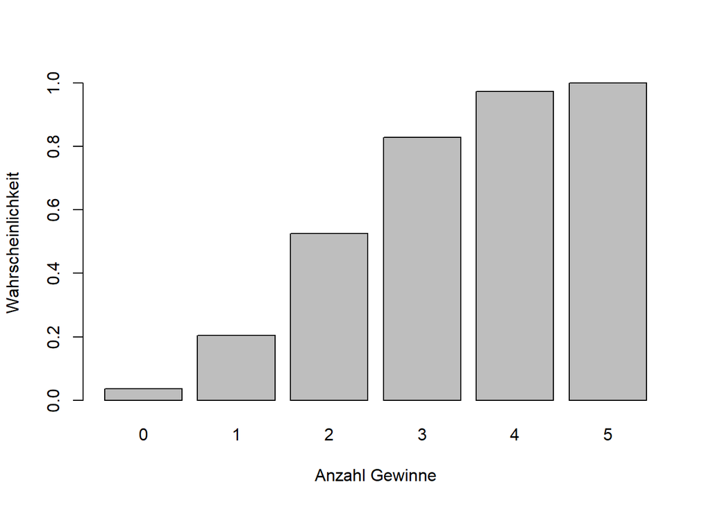

```r
barplot(pbinom(0:5, size=5, prob=18/37),
        xlab="Anzahl Gewinne", ylab = "Wahrscheinlichkeit", names=0:5)
```

Bestimmung der Gewinne, die in höchstens 90% der Fälle erreicht werden

```r
qbinom(0.9,5,18/37)
```

```
## [1] 4
```

## Aufgabe: Hypergeometrische Verteilung

### Aufgabe

Poker wird mit 52 Karten gespielt, jeweils 13 Karten der Farben ♥, ♦, ♣ und ♠. Bei der Variante Five-Card-Stud erhält jeder Spieler 5 Karten zufällig zugeteilt.

#### Frage 1. Wie gross ist die Wahrscheinlichkeit, dass der Spieler ein Flush (5 Karten derselben Farbe) erhält?

- N: Anzahl der Elemente in der Grundgesamtheit: 52
- M: Anzahl der Elemente, die für uns günstig sind : 13
- n: Grösse der Stichprobe : 5
- k: Anzahl der Elemente aus M, die in n enthalten sind : 5

Berechnung mit dhyper:

```r
round(dhyper (x=5, m=13, n=39, k=5), 6)
```

```
## [1] 0.000495
```

#### Frage 2. Wie gross ist die Wahrscheinlichkeit, dass der Spieler vier gleiche Karten erhält?

Berechnung mit dhyper:

```r
round(dhyper (x=4, m=13, n=39, k=5),6)
```

```
## [1] 0.010729
```

## Aufgabe: Poissonverteilung

Das Restaurant Fat’s Pizza führt Buch über die Anzahl an Gästen, die das Restaurant betreten. Laut der Aufzeichnungen ist der Erwartungswert µ = 12.1 zwischen 20:00 und 22:00 Uhr.

### Aufgabe

Bestimmen Sie mit der Poisson-Verteilung die Wahrscheinlichkeit, dass zwischen 20 Uhr und 22 Uhr folgende Szenarien auftauchen:

#### Grafische Darstellung

Zuerst betrachten wir die Verteilung in einer einfachen grafischen Darstellung (zwischen 0 und 20 Gäste im gegebenen Zeitintervall) :

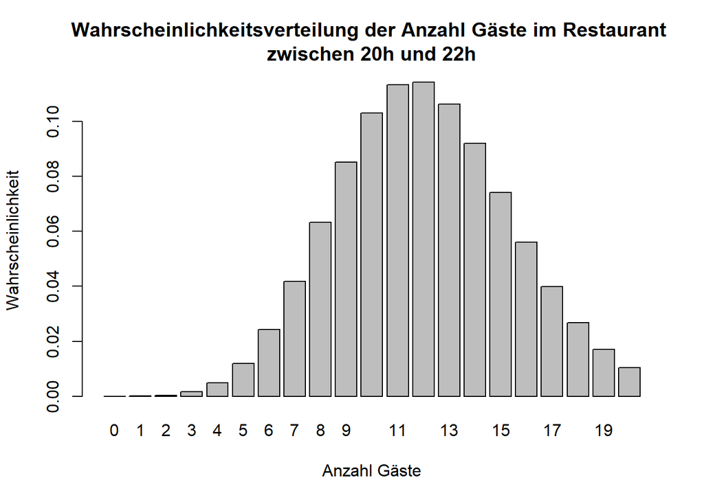

#### Frage 1. Wahrscheinlichkeit, dass genau 8 Gäste im Restaurant anwesend sind:

```r
round(dpois(8, lambda = 12.1), 4)
```

```
## [1] 0.0634
```

#### Frage 2. Wahrscheinlichkeit, dass höchstens 10 Gäste im Restaurant anwesend sind:

```r
round(ppois(10, lambda = 12.1, lower.tail = T ), 4)
```

```
## [1] 0.3368
```

#### Frage 3. Wahrscheinlichkeit, dass zwischen 9 und 15 Gäste im Restaurant anwesend sind:

```r
round((ppois(15, lambda = 12.1, lower.tail = T ) - ppois(9, lambda = 12.1, lower.tail = T )), 4)
```

```
## [1] 0.6033
```

```r
round(ppois(11, lambda = 12.1, lower.tail = F ), 4)
```

```
## [1] 0.5498
```